# The Bureaucracy

POLS 2311: Government of the United States

## Agenda

- Politics and Administration
- Bureaucracy and Government Agencies
- History of the Federal Bureaucracy
- Political Control

## Public Administration

### Federalist 72, Hamilton

> *The administration of government, in its largest sense, comprehends all the operations of the body politics, whether legislative, executive, or judiciary; but in its most usual and perhaps in its most precise signification, it is limited to executive details, and falls peculiarly within the province of the executive department*

[figure not shown]

## The Politics-Administration Dichotomy

**Woodrow Wilson: *administrative questions are not political questions***

**Politics**

- Decides what actions should be taken through debate
- *Values based*

**Administration**

- Implements policies made by elected officials
- *Expertise based*

## Democracy and Delegation

**The people $\rightarrow$ Elected officials $\rightarrow$ Government Agencies**

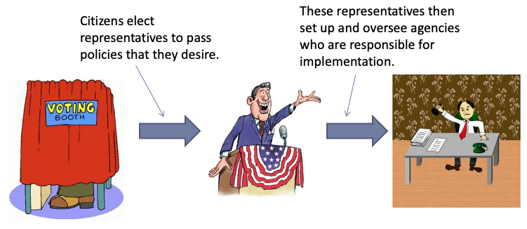

## The Administrative State

- *The various agencies of the executive branch as well they the various rules and regulations that those agencies have developed*
- Americans tend to like the effects of individual regulations and dislike the effects of regulations collectively

[figure not shown]

## Distinctiveness of the American Bureaucracy

- **Power is shared**: functions are divided among federal, state, and local agencies rather than concentrated in a single national bureaucracy
- **Proxy government**: state governments, local governments, and private groups receive federal funding to administer federal programs
  - Much of what functions as “federal” policy delivery is actually carried out by non-federal actors implementing federal rules and funding

# The Bureaucracy

# What comes to mind when you hear the term *bureaucracy*?

## Red Tape

[figure not shown]

## Hierarchy

[figure not shown]

## The Federal Bureaucracy

*The many arms of federal bureaucracy are often considered the fourth branch of government. This administrative structure, staffed by nonelected workers, enables the government to function as needed by citizens*

## Bureaucracy and Bureaucrat

- **Bureaucracy**: *An administrative group of non-elected officials charged with carrying out functions connected to a series of policies and programs*
  - A way to organize a large number of people toward a common purpose
- **Bureaucrat**: *An individual who works in the bureaucracy and fills the necessary and instrumental roles in every area of government*

## Bureaucracy

### Max Weber

- *Characteristics*
  - Hierarchy
  - Fixed rules
  - Impersonal relationships
  - Adherence to procedures
  - Highly specialized division of labor

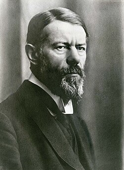

## Discretionary Authority

- **Discretionary Authority**: *The extent to which appointed bureaucrats can choose courses of action and make policies not spelled out in advance by laws*
- Legislatures cannot anticipate every contingency when writing statutes
- Discretion allows agencies to adapt policy using expertise — but raises questions about democratic accountability

## Federal Bureaucracy

- *Agencies in the Executive branch are one of three types*:
  - Cabinet department
  - Independent agency
  - Government corporation

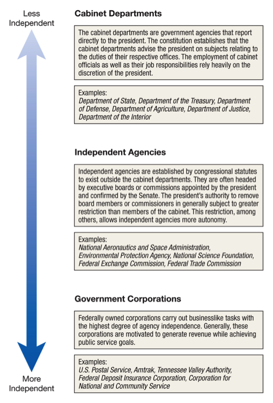

## Cabinet Departments

- Perform essential government functions
  - State, Treasury, War (Defense)
- Reflect needs of a growing nation
  - Justice, Interior
- Clientele
  - Agriculture, Commerce, and Labor
  - Health and Human Services, Education, Veterans Affairs
- National priorities
  - Housing and Urban Development, Energy, Homeland Security

## Independent Agencies

- e.g., NASA, EPA, FTC
- New ways to approach problems
- Avoid clientele pressure
- *Independence from the president* ???
- New functions

## Origins of Independent Agencies

- *Interstate Commerce Commission* (1887)
  - Western farmers complained railroad monopolies were gouging them on shipping rates
  - Congress distrusted president Grover Cleveland to stand up to railroad pressure
  - Solution: expert, insulated rate-setting by a multimember commission
- *Federal Trade Commission* (1914)
  - Modeled on the ICC’s independence
  - Progressive Era belief in expert, nonpartisan regulation

## Independent Agencies

- *Humphrey’s Executor v. United States* (1935)
  - FDR could not fire an FTC commissioner over policy disagreements
  - Congress can protect heads of multimember commissions (FTC, NLRB, SEC) from removal except “for cause”
  - Overruled by *Trump v. Slaughter* (2026): commissioners exercising “executive power” can be fired at will
  - Federal Reserve carved out in *Trump v. Cook* (2026)

## Government Corporations

- e.g., USPS, FDIC, TVA
- *Business corporations established by the federal government*
- Receive no congressional appropriations

## Civil Service

- The fall of political patronage practices led to the creation of the *Civil Service Reform Act of 1883*, establishing the Civil Service Commission, a centralized agency charged with hiring civil servants through a merit system
- Hiring practices and structured pay systems create an environment in which those most likely to succeed are in fact those who are ultimately appointed
- Preset examinations and civil service exams help determine required abilities and qualifications
- Civil servants receive pay based on the U.S. Federal General Schedule. The grades reflect different required competencies and education standards for various civil service positions
- The grade system provides a clear structure for merit-based advancement

## Civil Service

- Recruitment and Retention
  - Largely merit-based
  - The **buddy system**: many mid-to-upper-level positions filled via “name-request” jobs rather than open competition
- Firing
  - Termination of employees involves a process
  - **Senior Executive Service**: created in response to how difficult that process had become
- Makeup
  - Cross-spectrum of Americans in civil servant positions.
  - Disparities in who serves in highest positions.
    - Race, Gender, Education

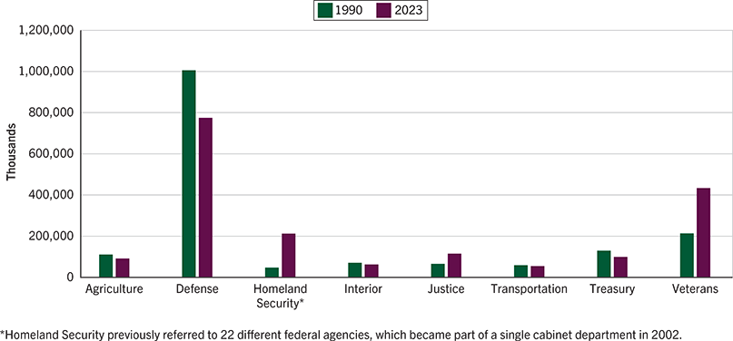

*Federal Civilian Employment, 1990–2023*

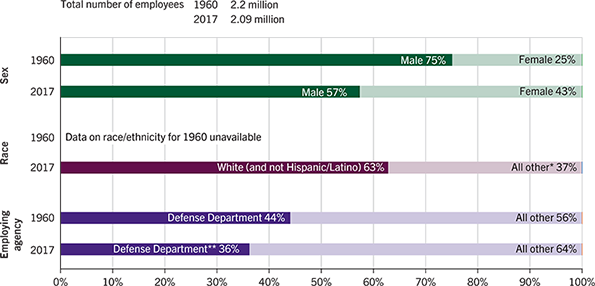

*Characteristics of Federal Civilian Employees, 1960 and 2017*

# History of the Federal Bureaucracy

## Copying the Crown

**The initial executive branch of government was similar to the administration of King George III**

- **Perform essential national government functions**
- Department of State (1789)
- Department of War (1789)
- Department of Treasury (1789)
- Office of Attorney General (1789)

[figure not shown]

## Historical Eras of Government Development

- Divided Power: 1789–1860
- State Activism: 1870–1936
- National Activism: 1936–1960
- National Standards: 1960–1980
- The End of Big Government: 1980–2024 (?)
- Trump 2.0 and the Unitary Executive: 2025-?
  - Reconstituting the Administrative State

## Divided Power: 1789–1860

- *Responsibility for many policy areas was with state government*
- The rise of centralized party politics in the 1820s, with many thousands of party loyalists, filled the ranks of bureaucratic offices around the country
- Most government agencies served the public but did not regulate

## State Activism: 1870–1936

- *Demands of the Industrial revolution*
- Industrialization in the late nineteenth century increased both the population and economic size of the United States, creating a need for more government programs to be staffed by *civil servants*
  - Interstate Commerce Commission (1887), the Federal Reserve Board (1913), the Federal Trade Commission (1914), Federal Power Commission (1920)
- Interstate Commerce Commission (ICC) created to *regulate* the economy

## Assassination of James Garfield

[figure not shown]

[figure not shown]

## National Activism: 1936–1960

- *The great depression and demands for action*
  - “Alphabet agencies”
- National Industrial Recovery Act (1933)
  - Public works
  - *Shifted authority to the president*
- Federal Deposit Insurance Corporation (FDIC) (1933), Securities and Exchange Commission (SEC) (1934), Social Security Administration (1935), Agriculture and farm programs, Department of Health, Education, and Welfare (1953)
- *People expected the government to deal with economic and social problems*

## National Standards: 1960–1980

- *The reinvigoration of national activism in the 1960s*
- Department of Housing and Urban Development (1965), Environmental Protection Agency (1970), Occupational Safety and Health Administration (1971), Department of Education (1979)
- The federal bureaucracy reflects the active role of the federal government

## The End of “Big Government” 1980–2024

### Which president said it?

> *Government cannot solve our problems, it can’t set our goals. It cannot define our vision. Government cannot eliminate poverty or provide a bountiful economy or reduce inflation or save our cities or cure illiteracy or provide energy. And government cannot mandate goodness*

## Jimmy Carter

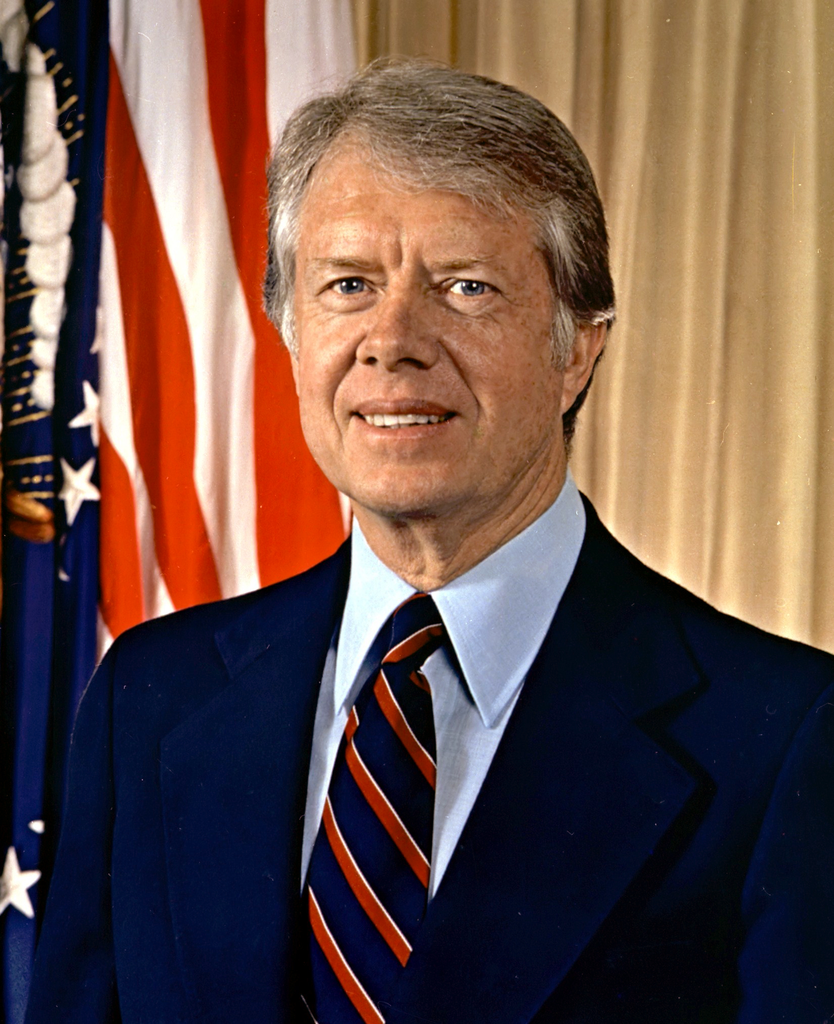

## The End of “Big Government” 1980–2024

### Which president said it?

> *We know big government does not have all the answers. We know there’s not program for every problem. We have worked to give the American people a smaller, less bureaucratic government in Washington. And we have to give the American people one that lives within its means. The era of big government is over*

## Bill Clinton

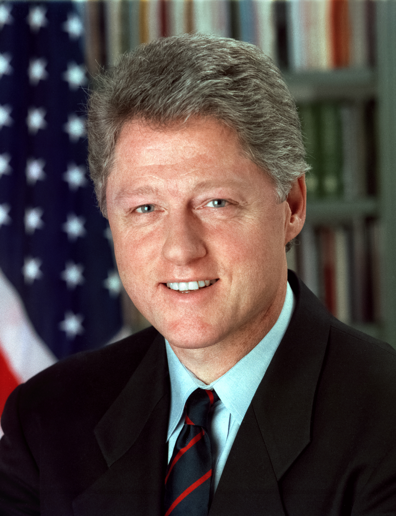

## The End of “Big Government” 1980–2024

- *Reform of the bureaucracy*
- Deregulation
- Privatization
  - *Government contracts* to private companies in order for them to provide necessary services
- Department of Government Efficiency (DOGE)

## Big Government?

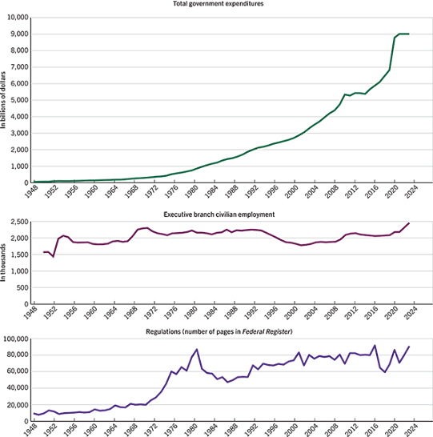

# Political Control

## Democracy and Delegation

**The people $\rightarrow$ Elected officials $\rightarrow$ Government Agencies**

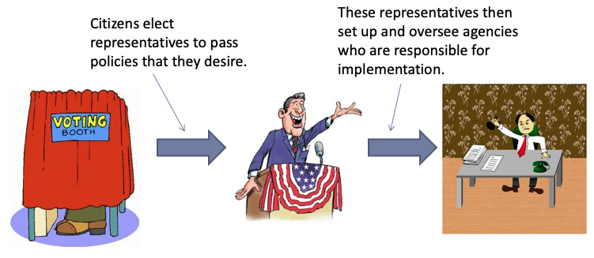

## Democracy and Delegation

- Congress has delegated substantial authority to administrative agencies in three areas:
  - Paying subsidies to particular groups and organizations in society
  - Transferring money from the federal government to state and local governments
  - *Devising and enforcing regulations* for various sectors of society and the economy

## Why Delegate?

- The bureaucracy has more expertise in these policy areas and more flexibility to make changes if necessary
- “Shift the responsibility” of decision-making to the agencies
  - Blame avoidance

## Agency Policymaking

- **Regulation**: *Specific standards or instructions concerning what individuals, businesses, and other organizations can or cannot do*
  - Most consequential form of executive branch policymaking
  - The *Take Care Clause*
- **Regulations are made through the *rulemaking* process**
- **Rulemaking**: *The agency process of translating congressional legislation into specific, actionable rules*
  - Rules must have statutory authority

## The Administrative Procedure Act (1946)

- **The agency can only act within the limits set by statute**
- The APA established the procedures an agency must follow to promulgate binding rules and regulations
- The agency must meet the following tests:
  - Be reasonable (sufficient factual support in the record)
  - Not be arbitrary or capricious
  - Not be an abuse of discretion
- Involves various stages and requires opportunities for public involvement

## The Rulemaking Process

[figure not shown]

## Drift and Divergent Policy Goals

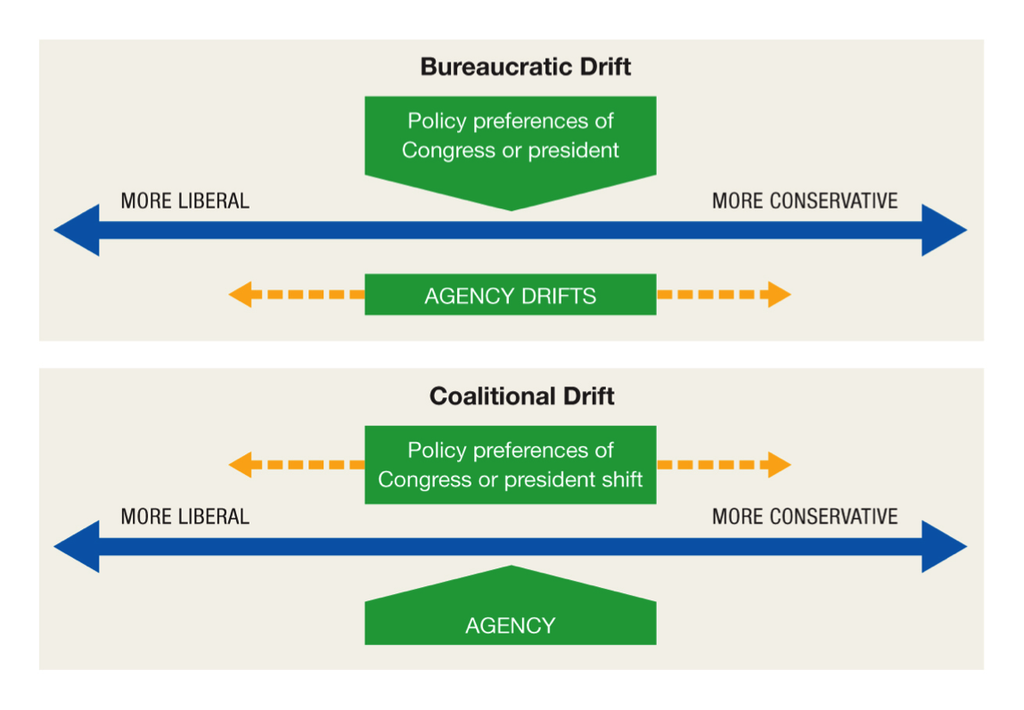

## Political Control

- **Political Control**:
  - External checks by political institutions
  - Elected officials use various oversight and control mechanisms to manage the bureaucracy
- Exercised by:
  - *The legislature*
  - *The executive*
  - *The judiciary*
  - **Federalism**

## Political Control

### Congress

- Authorization of agency
- Legislative language restricting discretion
- Budgetary control
- *Police patrol* oversight: Active monitoring
- *Fire alarm* oversight: React to complaints from citizens and/or interest groups

## Political Control

### President

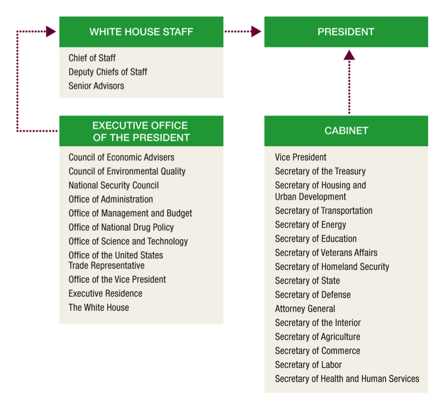

## Political Control

### President

- Appointment of sympathetic agency heads
- Regulatory review prior to final rule enactment
- Executive orders
- Changes in budget authority
- Bureaucratic reorganization plans

## Political Control

### Courts

- The courts review agency actions to determine if they meet constitutional or statutory requirements
  - Is the action consistent with legislative intent?
  - Were proper procedures followed?
- *Deference*

## Beyond Formal Checks: Informal Networks

- **Iron Triangle**: a stable, mutually reinforcing relationship among an agency, its congressional oversight committee, and the interest groups it regulates
- **Issue Network**: a looser, more contentious network of Washington-based interest groups, congressional staff, academics, think tanks, and mass media who discuss and advocate public policy
- Presidents often recruit agency officials directly from the relevant issue network

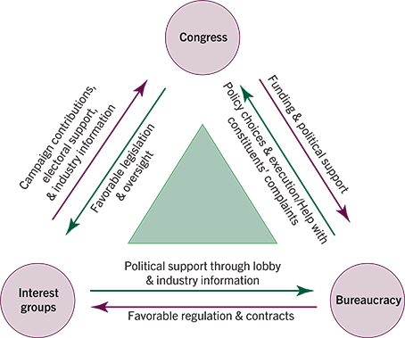

*Iron Triangle*

## The End of *Chevron* Deference

- Under *Chevron* (1984), courts deferred to a reasonable agency interpretation of an ambiguous statute — Congress was presumed to have implicitly delegated interpretive authority to the expert agency
- The **Major Questions Doctrine**: on questions of vast economic or political significance, courts should not defer to agency interpretations absent a clear congressional statement of authority
- In 2024, the Supreme Court overruled *Chevron* outright — eliminating agency deference across the board

## Has the Bureaucracy Gotten Too Powerful?

**What empowers the bureaucracy?**

- Knowledge and technical expertise
- Institutional knowledge
- Tenure of workers

**What limits the bureaucracy?**

- Strict limits on positions
- Constraints placed on agencies
- Congressional oversight

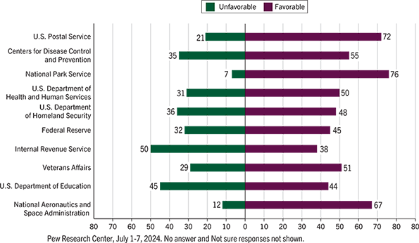

*How the Public Views Particular Federal Agencies*

# Reconstituting the Administrative State

## Schedule F and “New Patronage”

- **Schedule F**: reclassifies career civil servants in “policy-influencing” positions into the *excepted service*, removing at-will removal protections
- First created by executive order in 2020; revoked by Biden; reinstated by Trump on his first day back in office (2025)
- May be a **new patronage** — a 21st-century echo of Jacksonian patronage that prioritizes loyalty over merit and technical qualification
- Risks: incompetence, corruption, and a chilling effect on candid advice to political leadership

## Reconstituting the Administrative State

- Several 2020s Supreme Court decisions have reshaped the administrative state along two tracks
- **Reduced interpretive discretion**: the end of *Chevron* deference and the Major Questions Doctrine
- **Reduced structural independence**: *Trump v. Slaughter* (2026) overruled *Humphrey’s Executor*, holding officials exercising “executive power” may be removed by the president at will — the **Unitary Executive Theory**